# Covid_NYC_Counties

```r
library(tidycensus)
library(tidyverse)
library(lubridate)
library(modelr)
library(tigris)
library(sf)
library(dplyr)

readRenviron("~/.Renviron")

options(tigris_use_cache = TRUE)
```

```r
nyc_zip_codes <- read_csv("https://raw.githubusercontent.com/erikgregorywebb/nyc-housing/master/Data/nyc-zip-codes.csv") %>%
  rename(GEOID = ZipCode)
manhattan <- nyc_zip_codes %>%
  filter(Borough == "Manhattan")

queens <- nyc_zip_codes %>%
  filter(Borough == "Queens")
```

# Figure 1

## Manhattan

**Proportion of 18-64 year olds who are uninsured**

```r
manhattan_uninsured <- get_acs(geography = "zcta",
                        variables = c(uninsured_34 = "B27010_033", uninsured_64 = "B27010_050", total_34 = "B27010_018", total_64 = "B27010_034"),
                        state = "NY",
                        year = 2016,
                        geometry = TRUE) %>%
  select(GEOID:estimate) %>%
  filter(GEOID %in% manhattan$GEOID) %>%
  pivot_wider(names_from = variable, values_from = estimate) %>%
  group_by(GEOID) %>%
  mutate(uninsured = (uninsured_34 + uninsured_64) / (total_34 + total_64))
manhattan_uninsured %>%
  summary()
```

```
##     GEOID               NAME                    geometry     total_34
##  Length:43          Length:43          MULTIPOLYGON :43   Min.   :    0
##  Class :character   Class :character   epsg:4269    : 0   1st Qu.: 6830
##  Mode  :character   Mode  :character   +proj=long...: 0   Median :11569
##                                                           Mean   :12131
##                                                           3rd Qu.:16986
##                                                           Max.   :27831
##
##   uninsured_34       total_64      uninsured_64    uninsured
##  Min.   :   0.0   Min.   :    0   Min.   :   0   Min.   :0.01640
##  1st Qu.: 381.5   1st Qu.: 8268   1st Qu.: 437   1st Qu.:0.05253
##  Median : 843.0   Median :12785   Median : 884   Median :0.07404
##  Mean   :1300.7   Mean   :14411   Mean   :1335   Mean   :0.09107
##  3rd Qu.:1700.0   3rd Qu.:21864   3rd Qu.:2140   3rd Qu.:0.11828
##  Max.   :5154.0   Max.   :37745   Max.   :4030   Max.   :0.20555
##                                                  NA's   :1
```

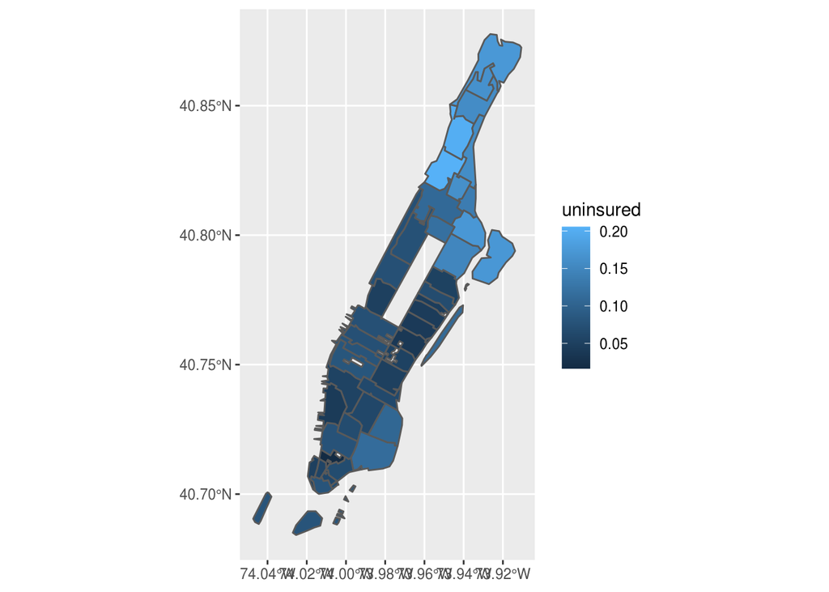

```r
ggplot(st_as_sf(manhattan_uninsured), aes(fill = uninsured)) +
  geom_sf()
```

**Median income (in millions, 2016$)**

```r
manhattan_med_income <- get_acs(geography = "zcta",
                         variables = c(medincome = "B19013_001"),
                         state = "NY",
                         year = 2016,
                         geometry = TRUE) %>%
  select(GEOID:estimate) %>%
  filter(GEOID %in% manhattan$GEOID) %>%
  mutate(med_income = estimate/1000000)
manhattan_med_income %>%
  summary()
```

```
##     GEOID               NAME             variable            estimate
##  Length:43          Length:43          Length:43          Min.   : 26893
##  Class :character   Class :character   Class :character   1st Qu.: 45946
##  Mode  :character   Mode  :character   Mode  :character   Median :101303
##                                                           Mean   : 88929
##                                                           3rd Qu.:114930
##                                                           Max.   :234958
##                                                           NA's   :1
##           geometry    med_income
##  MULTIPOLYGON :43   Min.   :0.02689
##  epsg:4269    : 0   1st Qu.:0.04595
##  +proj=long...: 0   Median :0.10130
##                     Mean   :0.08893
##                     3rd Qu.:0.11493
##                     Max.   :0.23496
##                     NA's   :1
```

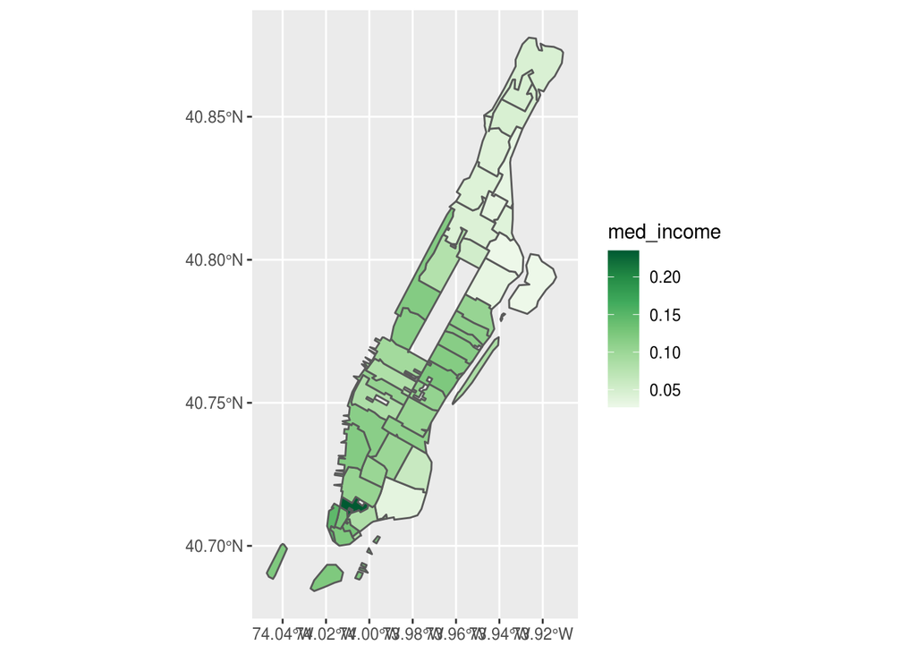

```r
ggplot(st_as_sf(manhattan_med_income), aes(fill = med_income)) +
  geom_sf() +
  scale_fill_distiller(palette = "Greens",
                       direction = 1)
```

**Proportion self-identifying as White**

```r
manhattan_prop_white <- get_acs(geography = "zcta",
                         variables = c(white_alone = "B02001_002", total = "B02001_001"),
                         state = "NY",
                         year = 2016,
                         geometry = TRUE) %>%
  select(GEOID:estimate) %>%
  filter(GEOID %in% manhattan$GEOID) %>%
  pivot_wider(names_from = variable, values_from = estimate) %>%
  mutate(white = white_alone/total)
manhattan_prop_white %>%
  summary()
```

```
##     GEOID               NAME                    geometry      total
##  Length:43          Length:43          MULTIPOLYGON :43   Min.   :    0
##  Class :character   Class :character   epsg:4269    : 0   1st Qu.:22816
##  Mode  :character   Mode  :character   +proj=long...: 0   Median :32854
##                                                           Mean   :37521
##                                                           3rd Qu.:57642
##                                                           Max.   :94717
##
##   white_alone        white
##  Min.   :    0   Min.   :0.1074
##  1st Qu.: 7535   1st Qu.:0.3715
##  Median :18565   Median :0.6599
##  Mean   :21346   Mean   :0.5898
##  3rd Qu.:27773   3rd Qu.:0.7739
##  Max.   :62509   Max.   :0.8892
##                  NA's   :1
```

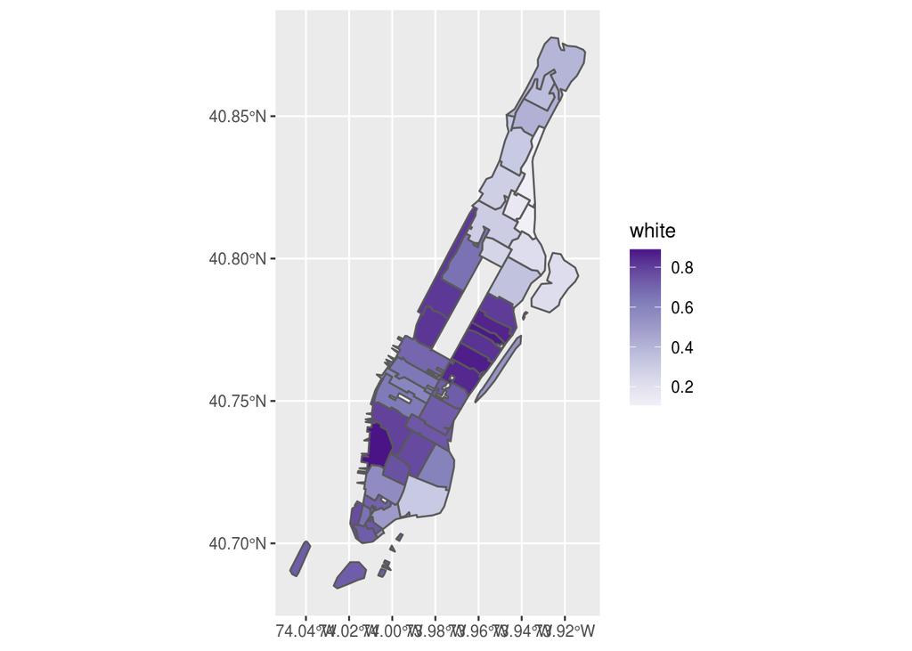

```r
ggplot(st_as_sf(manhattan_prop_white), aes(fill = white)) +
  geom_sf() +
  scale_fill_distiller(palette = "Purples",
                       direction = 1)
```

**Proportion of households of 4 or more**

```r
manhattan_prop_4 <- get_acs(geography = "zcta",
                         variables = c(four = "B11016_005", five = "B11016_006", six = "B11016_007", seven_more = "B11016_008", nf_four = "B11016_013", nf_five = "B11016_014", nf_six = "B11016_015", nf_seven = "B11016_016", total = "B11016_001"),
                         state = "NY",
                         year = 2016,
                         geometry = TRUE) %>%
  select(GEOID:estimate) %>%
  filter(GEOID %in% manhattan$GEOID) %>%
  pivot_wider(names_from = variable, values_from = estimate) %>%
  mutate(large_house = (four + five + six + seven_more + nf_four + nf_five + nf_six + nf_seven)/total)
manhattan_prop_4 %>%
  summary()
```

```
##     GEOID               NAME                    geometry      total
##  Length:43          Length:43          MULTIPOLYGON :43   Min.   :    0
##  Class :character   Class :character   epsg:4269    : 0   1st Qu.:10495
##  Mode  :character   Mode  :character   +proj=long...: 0   Median :16070
##                                                           Mean   :17307
##                                                           3rd Qu.:25198
##                                                           Max.   :42783
##
##       four             five             six          seven_more
##  Min.   :   0.0   Min.   :   0.0   Min.   :  0.0   Min.   :  0.00
##  1st Qu.: 471.5   1st Qu.: 111.5   1st Qu.: 23.5   1st Qu.:  0.00
##  Median :1066.0   Median : 256.0   Median : 60.0   Median : 22.00
##  Mean   :1205.0   Mean   : 419.4   Mean   :121.9   Mean   : 92.14
##  3rd Qu.:1921.0   3rd Qu.: 608.5   3rd Qu.:193.0   3rd Qu.:135.00
##  Max.   :3605.0   Max.   :1453.0   Max.   :638.0   Max.   :645.00
##
##     nf_four          nf_five           nf_six          nf_seven
##  Min.   :  0.00   Min.   :  0.00   Min.   : 0.000   Min.   : 0.0000
##  1st Qu.: 14.50   1st Qu.:  0.00   1st Qu.: 0.000   1st Qu.: 0.0000
##  Median : 49.00   Median :  0.00   Median : 0.000   Median : 0.0000
##  Mean   : 66.26   Mean   : 14.84   Mean   : 2.605   Mean   : 0.6047
##  3rd Qu.: 88.00   3rd Qu.: 18.00   3rd Qu.: 0.000   3rd Qu.: 0.0000
##  Max.   :471.00   Max.   :128.00   Max.   :38.000   Max.   :13.0000
##
##   large_house
##  Min.   :0.02516
##  1st Qu.:0.06583
##  Median :0.09722
##  Mean   :0.11128
##  3rd Qu.:0.15776
##  Max.   :0.23808
##  NA's   :1
```

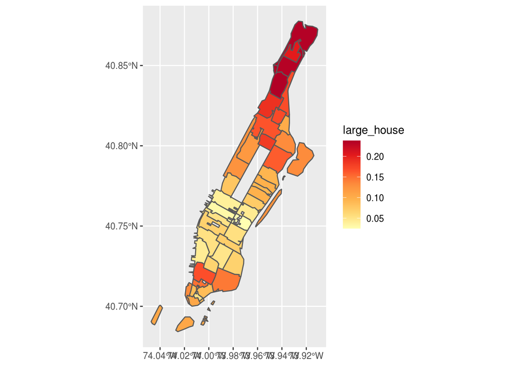

```r
ggplot(st_as_sf(manhattan_prop_4), aes(fill = large_house)) +
  geom_sf() +
  scale_fill_distiller(palette = "YlOrRd",
                       direction = 1)
```

**Proportion of population that commutes by bus**

```r
manhattan_prop_bus <- get_acs(geography = "zcta",
                         variables = c(bus = 'B08301_011', total = "B08301_001"),
                         state = "NY",
                         year = 2016,
                         geometry = TRUE) %>%
  select(GEOID:estimate) %>%
  filter(GEOID %in% manhattan$GEOID) %>%
  pivot_wider(names_from = variable, values_from = estimate) %>%
  mutate(prop_bus = bus/total)
manhattan_prop_bus %>%
  summary()
```

```
##     GEOID               NAME                    geometry      total
##  Length:43          Length:43          MULTIPOLYGON :43   Min.   :    0
##  Class :character   Class :character   epsg:4269    : 0   1st Qu.:11802
##  Mode  :character   Mode  :character   +proj=long...: 0   Median :18914
##                                                           Mean   :20111
##                                                           3rd Qu.:30582
##                                                           Max.   :47089
##
##       bus          prop_bus
##  Min.   :   0   Min.   :0.002866
##  1st Qu.: 364   1st Qu.:0.035368
##  Median :1242   Median :0.067622
##  Mean   :1395   Mean   :0.062500
##  3rd Qu.:2168   3rd Qu.:0.091051
##  Max.   :3844   Max.   :0.119889
##                 NA's   :1
```

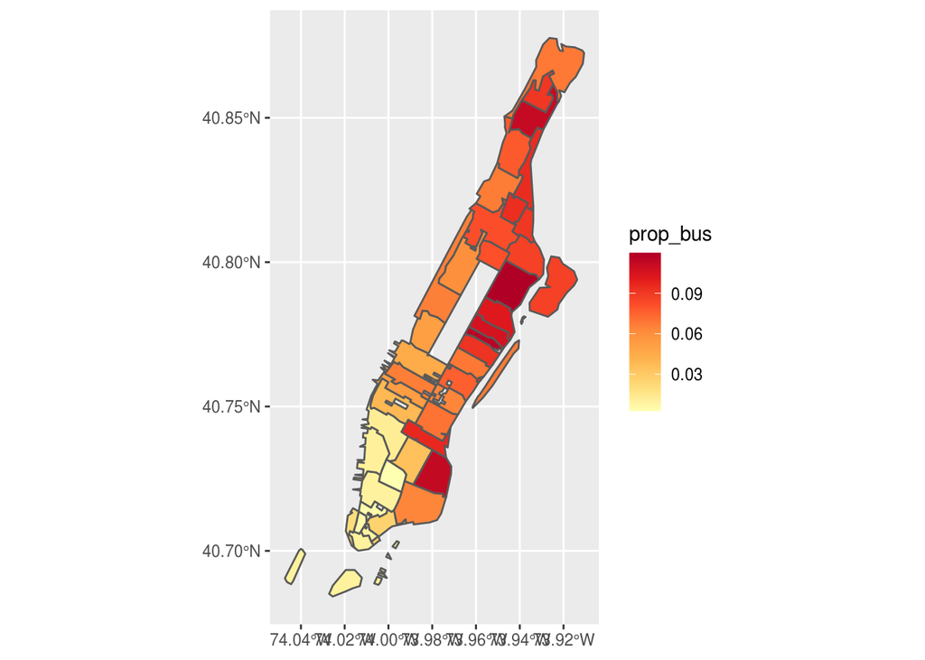

```r
ggplot(st_as_sf(manhattan_prop_bus), aes(fill = prop_bus)) +
  geom_sf() +
  scale_fill_distiller(palette = "YlOrRd",
                       direction = 1)
```

**Proportion of population 65+ years of age**

```r
manhattan_prop_65yrs <- get_acs(geography = "zcta",
                         variables = c(m65 = "B01001_020", m67 = "B01001_021", m70 = "B01001_022", m75 = "B01001_023", m80 = "B01001_024", m85 = "B01001_025", f_65 = "B01001_044", f_67 = "B01001_045", f_70 = "B01001_046", f_75 = "B01001_047", f_80 = "B01001_048", f_85 = "B01001_049", total = "B01001_001"),
                         state = "NY",
                         year = 2016,
                         geometry = TRUE) %>%
  select(GEOID:estimate) %>%
  filter(GEOID %in% manhattan$GEOID) %>%
  pivot_wider(names_from = variable, values_from = estimate) %>%
  mutate(elderly = (m65 + m67 + m70 + m75 + m80 + m85 + f_65 + f_67 + f_70 + f_75 + f_80 + f_85)/total)
manhattan_prop_65yrs %>%
  summary()
```

```
##     GEOID               NAME                    geometry      total
##  Length:43          Length:43          MULTIPOLYGON :43   Min.   :    0
##  Class :character   Class :character   epsg:4269    : 0   1st Qu.:22816
##  Mode  :character   Mode  :character   +proj=long...: 0   Median :32854
##                                                           Mean   :37521
##                                                           3rd Qu.:57642
##                                                           Max.   :94717
##
##       m65             m67              m70              m75
##  Min.   :  0.0   Min.   :   0.0   Min.   :   0.0   Min.   :   0.0
##  1st Qu.:153.0   1st Qu.: 180.5   1st Qu.: 227.5   1st Qu.: 208.5
##  Median :290.0   Median : 356.0   Median : 551.0   Median : 351.0
##  Mean   :315.6   Mean   : 393.4   Mean   : 563.7   Mean   : 379.7
##  3rd Qu.:455.0   3rd Qu.: 605.5   3rd Qu.: 815.5   3rd Qu.: 542.0
##  Max.   :878.0   Max.   :1230.0   Max.   :1617.0   Max.   :1091.0
##
##       m80              m85              f_65             f_67
##  Min.   :   0.0   Min.   :   0.0   Min.   :   0.0   Min.   :   0.0
##  1st Qu.: 113.5   1st Qu.:  57.0   1st Qu.: 173.5   1st Qu.: 263.0
##  Median : 206.0   Median : 187.0   Median : 443.0   Median : 524.0
##  Mean   : 273.0   Mean   : 275.5   Mean   : 432.5   Mean   : 546.0
##  3rd Qu.: 375.0   3rd Qu.: 406.5   3rd Qu.: 650.0   3rd Qu.: 713.5
##  Max.   :1176.0   Max.   :1014.0   Max.   :1241.0   Max.   :1910.0
##
##       f_70             f_75             f_80             f_85
##  Min.   :   0.0   Min.   :   0.0   Min.   :   0.0   Min.   :   0.0
##  1st Qu.: 364.0   1st Qu.: 228.0   1st Qu.: 142.5   1st Qu.: 251.5
##  Median : 631.0   Median : 412.0   Median : 383.0   Median : 476.0
##  Mean   : 746.3   Mean   : 532.7   Mean   : 417.9   Mean   : 549.4
##  3rd Qu.:1098.0   3rd Qu.: 855.5   3rd Qu.: 608.5   3rd Qu.: 775.0
##  Max.   :2634.0   Max.   :1561.0   Max.   :1279.0   Max.   :1784.0
##
##     elderly
##  Min.   :0.0000
##  1st Qu.:0.1005
##  Median :0.1295
##  Mean   :0.1321
##  3rd Qu.:0.1731
##  Max.   :0.2787
##  NA's   :1
```

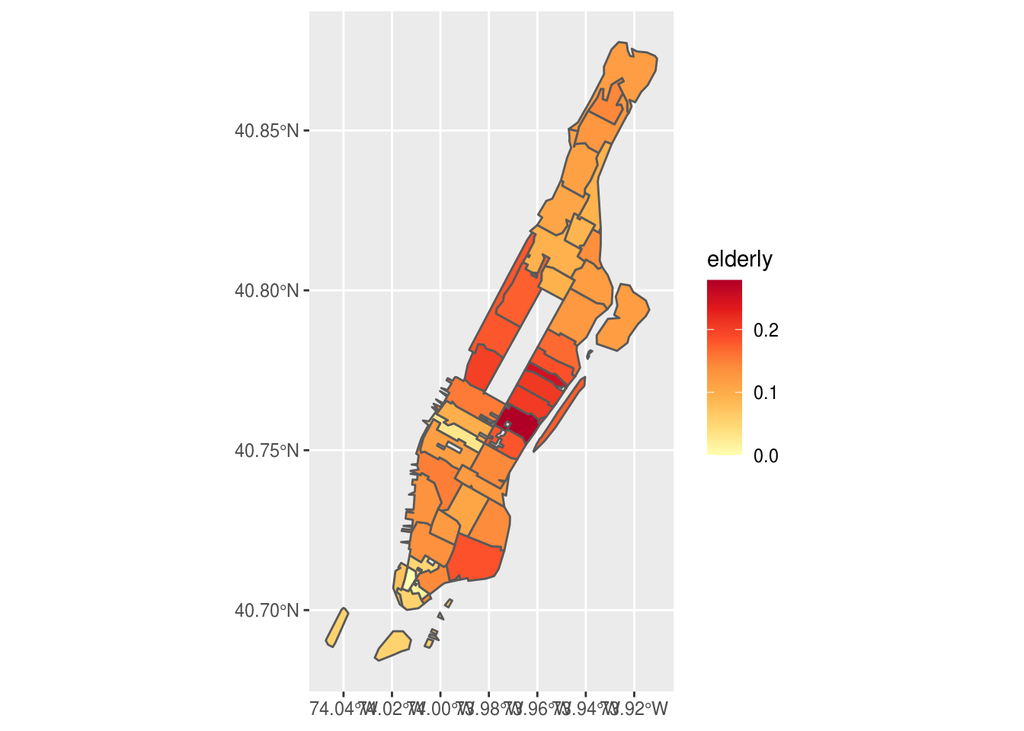

```r
ggplot(st_as_sf(manhattan_prop_65yrs), aes(fill = elderly)) +
  geom_sf() +
  scale_fill_distiller(palette = "YlOrRd",
                       direction = 1)
```

**APRIL 1**

```r
april_1 <- read_csv("https://raw.githubusercontent.com/nychealth/coronavirus-data/097cbd70aa00eb635b17b177bc4546b2fce21895/tests-by-zcta.csv") %>%
  mutate(pos_prop = Positive/Total) %>%
  rename(GEOID = MODZCTA) %>%
  select(GEOID, Positive:pos_prop)
df_list_manhattan <- list(manhattan_uninsured, manhattan_med_income, manhattan_prop_white, manhattan_prop_4, manhattan_prop_bus, manhattan_prop_65yrs)

all_df_manhattan <- df_list_manhattan %>%
  reduce(full_join, by = "GEOID") %>%
  select(GEOID, uninsured, med_income, white, large_house, prop_bus, elderly)

lm_all_manhattan <- merge(all_df_manhattan, april_1, by = "GEOID") %>%
  select(GEOID, uninsured:pos_prop)
```

*Univariate Linear Models*

**Proportion of 4-Person Household**

```r
lmfit_manhattan_4 <- lm(pos_prop ~ large_house, data = lm_all_manhattan)

summary(lmfit_manhattan_4)
```

```
##
## Call:
## lm(formula = pos_prop ~ large_house, data = lm_all_manhattan)
##
## Residuals:
##       Min        1Q    Median        3Q       Max
## -0.155750 -0.043578 -0.002043  0.050536  0.119639
##
## Coefficients:
##             Estimate Std. Error t value Pr(>|t|)
## (Intercept)  0.35194    0.02167  16.238  < 2e-16 ***
## large_house  0.61656    0.17239   3.577 0.000929 ***
## ---
## Signif. codes:  0 '***' 0.001 '**' 0.01 '*' 0.05 '.' 0.1 ' ' 1
##
## Residual standard error: 0.06539 on 40 degrees of freedom
## Multiple R-squared:  0.2423, Adjusted R-squared:  0.2234
## F-statistic: 12.79 on 1 and 40 DF,  p-value: 0.0009288
```

**Proportion of People 18-64 Years Old that are Uninsured**

```r
lmfit_manhattan_uninsured <- lm(pos_prop ~ uninsured, data = lm_all_manhattan)

summary(lmfit_manhattan_uninsured)
```

```
##
## Call:
## lm(formula = pos_prop ~ uninsured, data = lm_all_manhattan)
##
## Residuals:
##      Min       1Q   Median       3Q      Max
## -0.13626 -0.03589  0.00201  0.03433  0.11643
##
## Coefficients:
##             Estimate Std. Error t value Pr(>|t|)
## (Intercept)  0.33074    0.01843  17.947  < 2e-16 ***
## uninsured    0.98611    0.17824   5.532 2.14e-06 ***
## ---
## Signif. codes:  0 '***' 0.001 '**' 0.01 '*' 0.05 '.' 0.1 ' ' 1
##
## Residual standard error: 0.05654 on 40 degrees of freedom
## Multiple R-squared:  0.4335, Adjusted R-squared:  0.4193
## F-statistic: 30.61 on 1 and 40 DF,  p-value: 2.144e-06
```

**Proportion Self-Identifying as White**

```r
lmfit_manhattan_white <- lm(pos_prop ~ white, data = lm_all_manhattan)

summary(lmfit_manhattan_white)
```

```
##
## Call:
## lm(formula = pos_prop ~ white, data = lm_all_manhattan)
##
## Residuals:
##      Min       1Q   Median       3Q      Max
## -0.15688 -0.04242  0.00089  0.02877  0.11940
##
## Coefficients:
##             Estimate Std. Error t value Pr(>|t|)
## (Intercept)  0.53587    0.02471  21.684  < 2e-16 ***
## white       -0.19552    0.03897  -5.017 1.12e-05 ***
## ---
## Signif. codes:  0 '***' 0.001 '**' 0.01 '*' 0.05 '.' 0.1 ' ' 1
##
## Residual standard error: 0.05885 on 40 degrees of freedom
## Multiple R-squared:  0.3863, Adjusted R-squared:  0.3709
## F-statistic: 25.17 on 1 and 40 DF,  p-value: 1.12e-05
```

**Median Income**

```r
lmfit_manhattan_med_income <- lm(pos_prop ~ med_income, data = lm_all_manhattan)

summary(lmfit_manhattan_med_income)
```

```
##
## Call:
## lm(formula = pos_prop ~ med_income, data = lm_all_manhattan)
##
## Residuals:
##       Min        1Q    Median        3Q       Max
## -0.133199 -0.046445 -0.002309  0.041077  0.119521
##
## Coefficients:
##             Estimate Std. Error t value Pr(>|t|)
## (Intercept)  0.51171    0.02257   22.67  < 2e-16 ***
## med_income  -1.02509    0.23037   -4.45  6.7e-05 ***
## ---
## Signif. codes:  0 '***' 0.001 '**' 0.01 '*' 0.05 '.' 0.1 ' ' 1
##
## Residual standard error: 0.06143 on 40 degrees of freedom
## Multiple R-squared:  0.3311, Adjusted R-squared:  0.3144
## F-statistic:  19.8 on 1 and 40 DF,  p-value: 6.704e-05
```

**Proportion of People Who Commute by Bus**

```r
lmfit_manhattan_bus <- lm(pos_prop ~ prop_bus, data = lm_all_manhattan)

summary(lmfit_manhattan_bus)
```

```
##
## Call:
## lm(formula = pos_prop ~ prop_bus, data = lm_all_manhattan)
##
## Residuals:
##       Min        1Q    Median        3Q       Max
## -0.136569 -0.053986 -0.005085  0.063109  0.146779
##
## Coefficients:
##             Estimate Std. Error t value Pr(>|t|)
## (Intercept)  0.38342    0.02276   16.85   <2e-16 ***
## prop_bus     0.59408    0.31771    1.87   0.0688 .
## ---
## Signif. codes:  0 '***' 0.001 '**' 0.01 '*' 0.05 '.' 0.1 ' ' 1
##
## Residual standard error: 0.07203 on 40 degrees of freedom
## Multiple R-squared:  0.08039,    Adjusted R-squared:  0.0574
## F-statistic: 3.497 on 1 and 40 DF,  p-value: 0.06883
```

**Proportion Elderly (65+ years)**

```r
lmfit_manhattan_elderly <- lm(pos_prop ~ elderly, data = lm_all_manhattan)

summary(lmfit_manhattan_elderly)
```

```
##
## Call:
## lm(formula = pos_prop ~ elderly, data = lm_all_manhattan)
##
## Residuals:
##       Min        1Q    Median        3Q       Max
## -0.173662 -0.047699 -0.000439  0.037791  0.163999
##
## Coefficients:
##             Estimate Std. Error t value Pr(>|t|)
## (Intercept)  0.42366    0.02940  14.410   <2e-16 ***
## elderly     -0.02357    0.20457  -0.115    0.909
## ---
## Signif. codes:  0 '***' 0.001 '**' 0.01 '*' 0.05 '.' 0.1 ' ' 1
##
## Residual standard error: 0.0751 on 40 degrees of freedom
## Multiple R-squared:  0.0003319,  Adjusted R-squared:  -0.02466
## F-statistic: 0.01328 on 1 and 40 DF,  p-value: 0.9088
```

*Multivariate Linear Models (Table 1)*

**3 variables: uninsured, white, median income**

```r
lmfit_best_manhattan <- lm(pos_prop ~ uninsured + white + med_income, data = lm_all_manhattan)

summary(lmfit_best_manhattan)
```

```
##
## Call:
## lm(formula = pos_prop ~ uninsured + white + med_income, data = lm_all_manhattan)
##
## Residuals:
##       Min        1Q    Median        3Q       Max
## -0.140948 -0.041564  0.008949  0.036289  0.114027
##
## Coefficients:
##             Estimate Std. Error t value Pr(>|t|)
## (Intercept)  0.39352    0.08879   4.432 7.69e-05 ***
## uninsured    0.71780    0.42497   1.689   0.0994 .
## white       -0.06445    0.07868  -0.819   0.4178
## med_income  -0.00366    0.42612  -0.009   0.9932
## ---
## Signif. codes:  0 '***' 0.001 '**' 0.01 '*' 0.05 '.' 0.1 ' ' 1
##
## Residual standard error: 0.05746 on 38 degrees of freedom
## Multiple R-squared:  0.4441, Adjusted R-squared:  0.4002
## F-statistic: 10.12 on 3 and 38 DF,  p-value: 4.927e-05
```

## Queens

**Proportion of 18-64 year olds who are uninsured**

```r
queens_uninsured <- get_acs(geography = "zcta",
                        variables = c(uninsured_34 = "B27010_033", uninsured_64 = "B27010_050", total_34 = "B27010_018", total_64 = "B27010_034"),
                        state = "NY",
                        year = 2016,
                        geometry = TRUE) %>%
  select(GEOID:estimate) %>%
  filter(GEOID %in% queens$GEOID) %>%
  pivot_wider(names_from = variable, values_from = estimate) %>%
  group_by(GEOID) %>%
  mutate(uninsured = (uninsured_34 + uninsured_64) / (total_34 + total_64))
queens_uninsured %>%
  summary()
```

```
##     GEOID               NAME                    geometry     total_34
##  Length:60          Length:60          MULTIPOLYGON :60   Min.   :    0
##  Class :character   Class :character   epsg:4269    : 0   1st Qu.: 4779
##  Mode  :character   Mode  :character   +proj=long...: 0   Median : 8128
##                                                           Mean   : 9614
##                                                           3rd Qu.:13001
##                                                           Max.   :33116
##
##   uninsured_34      total_64      uninsured_64       uninsured
##  Min.   :    0   Min.   :    0   Min.   :    0.0   Min.   :0.0000
##  1st Qu.:  749   1st Qu.: 8584   1st Qu.:  998.2   1st Qu.:0.1121
##  Median : 1476   Median :13667   Median : 1816.5   Median :0.1424
##  Mean   : 2175   Mean   :15527   Mean   : 2738.7   Mean   :0.1610
##  3rd Qu.: 2636   3rd Qu.:18849   3rd Qu.: 2907.8   3rd Qu.:0.2050
##  Max.   :16667   Max.   :42170   Max.   :15180.0   Max.   :0.4351
##                                                    NA's   :1
```

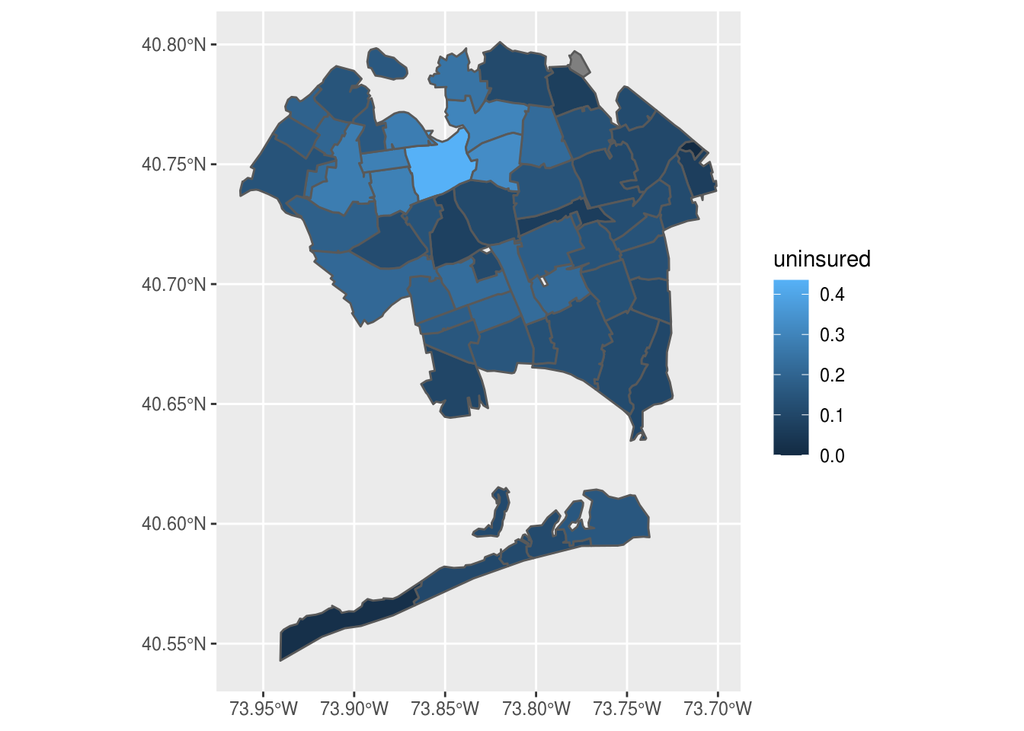

```r
ggplot(st_as_sf(queens_uninsured), aes(fill = uninsured)) +
  geom_sf()
```

**Median income (in millions, 2016$)**

```r
queens_med_income <- get_acs(geography = "zcta",
                         variables = c(medincome = "B19013_001"),
                         state = "NY",
                         year = 2016,
                         geometry = TRUE) %>%
  select(GEOID:estimate) %>%
  filter(GEOID %in% queens$GEOID) %>%
  mutate(med_income = estimate/1000000)
queens_med_income %>%
  summary()
```

```
##     GEOID               NAME             variable            estimate
##  Length:60          Length:60          Length:60          Min.   : 38451
##  Class :character   Class :character   Class :character   1st Qu.: 55409
##  Mode  :character   Mode  :character   Mode  :character   Median : 62841
##                                                           Mean   : 64375
##                                                           3rd Qu.: 73618
##                                                           Max.   :100909
##                                                           NA's   :1
##           geometry    med_income
##  MULTIPOLYGON :60   Min.   :0.03845
##  epsg:4269    : 0   1st Qu.:0.05541
##  +proj=long...: 0   Median :0.06284
##                     Mean   :0.06437
##                     3rd Qu.:0.07362
##                     Max.   :0.10091
##                     NA's   :1
```

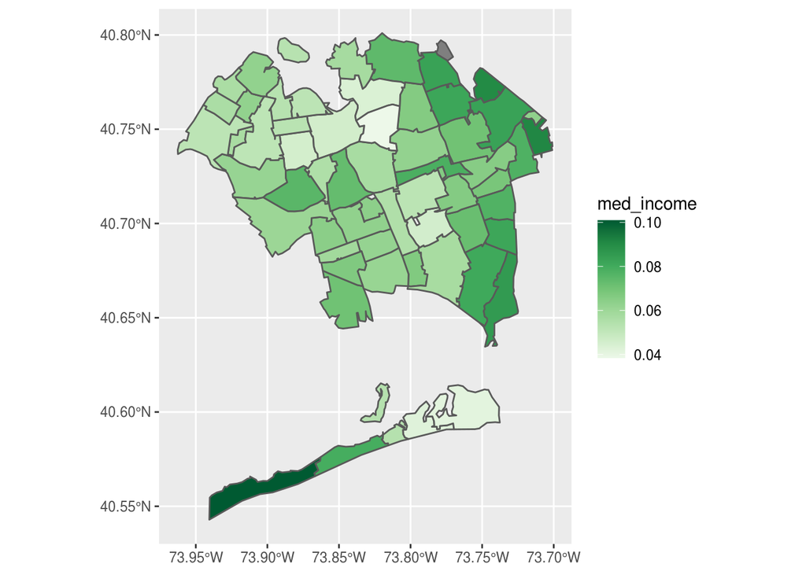

```r
ggplot(st_as_sf(queens_med_income), aes(fill = med_income)) +
  geom_sf() +
  scale_fill_distiller(palette = "Greens",
                       direction = 1)
```

**Proportion self-identifying as White**

```r
queens_prop_white <- get_acs(geography = "zcta",
                         variables = c(white_alone = "B02001_002", total = "B02001_001"),
                         state = "NY",
                         year = 2016,
                         geometry = TRUE) %>%
  select(GEOID:estimate) %>%
  filter(GEOID %in% queens$GEOID) %>%
  pivot_wider(names_from = variable, values_from = estimate) %>%
  mutate(white = white_alone/total)
queens_prop_white %>%
  summary()
```

```
##     GEOID               NAME                    geometry      total
##  Length:60          Length:60          MULTIPOLYGON :60   Min.   :     0
##  Class :character   Class :character   epsg:4269    : 0   1st Qu.: 20948
##  Mode  :character   Mode  :character   +proj=long...: 0   Median : 34574
##                                                           Mean   : 38437
##                                                           3rd Qu.: 43660
##                                                           Max.   :112982
##
##   white_alone        white
##  Min.   :    0   Min.   :0.02264
##  1st Qu.: 5812   1st Qu.:0.22622
##  Median :12370   Median :0.41673
##  Mean   :15529   Mean   :0.42838
##  3rd Qu.:22001   3rd Qu.:0.60255
##  Max.   :85096   Max.   :0.99013
##                  NA's   :1
```

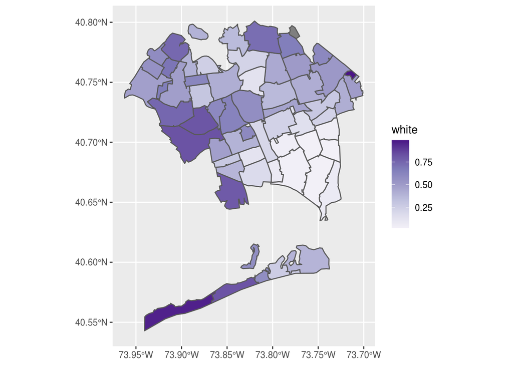

```r
ggplot(st_as_sf(queens_prop_white), aes(fill = white)) +
  geom_sf() +
  scale_fill_distiller(palette = "Purples",
                       direction = 1)
```

**Proportion of households of 4 or more**

```r
queens_prop_4 <- get_acs(geography = "zcta",
                         variables = c(four = "B11016_005", five = "B11016_006", six = "B11016_007", seven_more = "B11016_008", nf_four = "B11016_013", nf_five = "B11016_014", nf_six = "B11016_015", nf_seven = "B11016_016", total = "B11016_001"),
                         state = "NY",
                         year = 2016,
                         geometry = TRUE) %>%
  select(GEOID:estimate) %>%
  filter(GEOID %in% queens$GEOID) %>%
  pivot_wider(names_from = variable, values_from = estimate) %>%
  mutate(large_house = (four + five + six + seven_more + nf_four + nf_five + nf_six + nf_seven)/total)
queens_prop_4 %>%
  summary()
```

```
##     GEOID               NAME                    geometry      total
##  Length:60          Length:60          MULTIPOLYGON :60   Min.   :    0
##  Class :character   Class :character   epsg:4269    : 0   1st Qu.: 7437
##  Mode  :character   Mode  :character   +proj=long...: 0   Median :11281
##                                                           Mean   :12908
##                                                           3rd Qu.:15692
##                                                           Max.   :34919
##
##       four           five             six           seven_more
##  Min.   :   0   Min.   :   0.0   Min.   :   0.0   Min.   :   0.0
##  1st Qu.:1058   1st Qu.: 465.2   1st Qu.: 191.8   1st Qu.: 120.8
##  Median :1692   Median : 823.5   Median : 302.0   Median : 206.5
##  Mean   :1897   Mean   : 930.4   Mean   : 400.9   Mean   : 330.4
##  3rd Qu.:2314   3rd Qu.:1149.5   3rd Qu.: 549.0   3rd Qu.: 466.0
##  Max.   :5492   Max.   :3254.0   Max.   :2084.0   Max.   :2326.0
##
##     nf_four          nf_five          nf_six           nf_seven
##  Min.   :  0.00   Min.   : 0.00   Min.   :  0.000   Min.   : 0.000
##  1st Qu.:  3.75   1st Qu.: 0.00   1st Qu.:  0.000   1st Qu.: 0.000
##  Median : 16.00   Median : 6.00   Median :  0.000   Median : 0.000
##  Mean   : 44.80   Mean   :17.77   Mean   :  8.317   Mean   : 1.433
##  3rd Qu.: 49.75   3rd Qu.:21.75   3rd Qu.:  5.500   3rd Qu.: 0.000
##  Max.   :307.00   Max.   :90.00   Max.   :115.000   Max.   :23.000
##
##   large_house
##  Min.   :0.0000
##  1st Qu.:0.2271
##  Median :0.2775
##  Mean   :0.2843
##  3rd Qu.:0.3620
##  Max.   :0.5146
##  NA's   :1
```

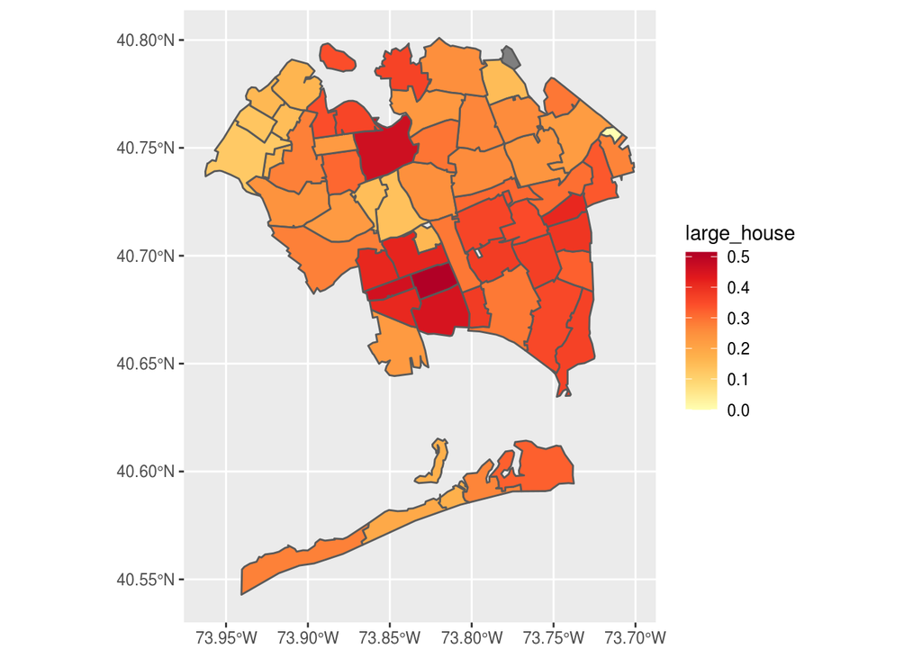

```r
ggplot(st_as_sf(queens_prop_4), aes(fill = large_house)) +
  geom_sf() +
  scale_fill_distiller(palette = "YlOrRd",
                       direction = 1)
```

**Proportion of population that commutes by bus**

```r
queens_prop_bus <- get_acs(geography = "zcta",
                         variables = c(bus = 'B08301_011', total = "B08301_001"),
                         state = "NY",
                         year = 2016,
                         geometry = TRUE) %>%
  select(GEOID:estimate) %>%
  filter(GEOID %in% queens$GEOID) %>%
  pivot_wider(names_from = variable, values_from = estimate) %>%
  mutate(prop_bus = bus/total)
queens_prop_bus %>%
  summary()
```

```
##     GEOID               NAME                    geometry      total
##  Length:60          Length:60          MULTIPOLYGON :60   Min.   :    0
##  Class :character   Class :character   epsg:4269    : 0   1st Qu.: 9836
##  Mode  :character   Mode  :character   +proj=long...: 0   Median :16650
##                                                           Mean   :18075
##                                                           3rd Qu.:21966
##                                                           Max.   :51837
##
##       bus            prop_bus
##  Min.   :   0.0   Min.   :0.00000
##  1st Qu.: 919.8   1st Qu.:0.07385
##  Median :1638.0   Median :0.11297
##  Mean   :2026.5   Mean   :0.11342
##  3rd Qu.:3156.5   3rd Qu.:0.15769
##  Max.   :6092.0   Max.   :0.23669
##                   NA's   :1
```

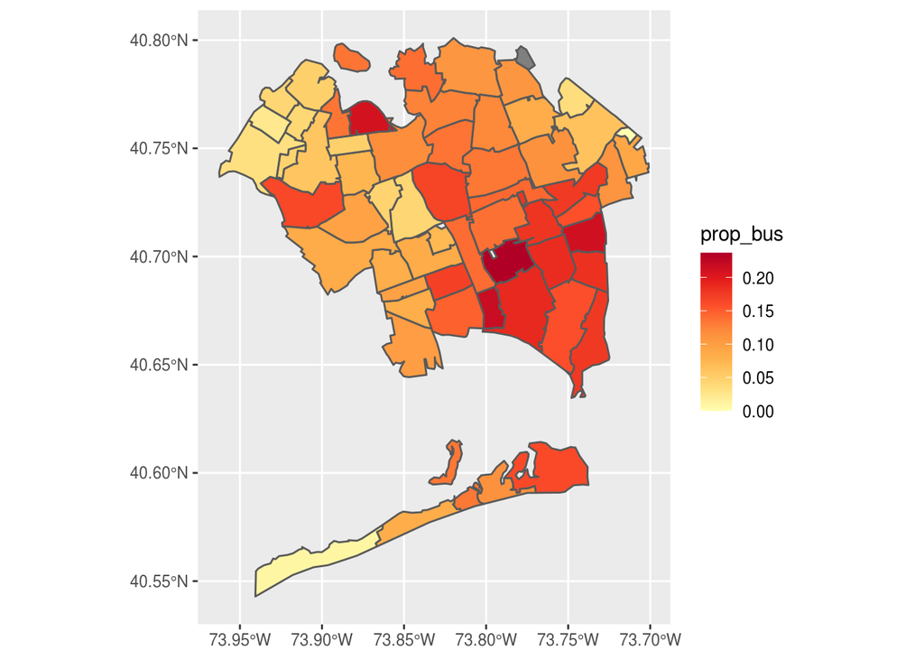

```r
ggplot(st_as_sf(queens_prop_bus), aes(fill = prop_bus)) +
  geom_sf() +
  scale_fill_distiller(palette = "YlOrRd",
                       direction = 1)
```

**Proportion of population 65+ years of age**

```r
queens_prop_65yrs <- get_acs(geography = "zcta",
                         variables = c(m65 = "B01001_020", m67 = "B01001_021", m70 = "B01001_022", m75 = "B01001_023", m80 = "B01001_024", m85 = "B01001_025", f_65 = "B01001_044", f_67 = "B01001_045", f_70 = "B01001_046", f_75 = "B01001_047", f_80 = "B01001_048", f_85 = "B01001_049", total = "B01001_001"),
                         state = "NY",
                         year = 2016,
                         geometry = TRUE) %>%
  select(GEOID:estimate) %>%
  filter(GEOID %in% queens$GEOID) %>%
  pivot_wider(names_from = variable, values_from = estimate) %>%
  mutate(elderly = (m65 + m67 + m70 + m75 + m80 + m85 + f_65 + f_67 + f_70 + f_75 + f_80 + f_85)/total)
queens_prop_65yrs %>%
  summary()
```

```
##     GEOID               NAME                    geometry      total
##  Length:60          Length:60          MULTIPOLYGON :60   Min.   :     0
##  Class :character   Class :character   epsg:4269    : 0   1st Qu.: 20948
##  Mode  :character   Mode  :character   +proj=long...: 0   Median : 34574
##                                                           Mean   : 38437
##                                                           3rd Qu.: 43660
##                                                           Max.   :112982
##
##       m65             m67              m70              m75
##  Min.   :  0.0   Min.   :   0.0   Min.   :   0.0   Min.   :   0.0
##  1st Qu.:216.0   1st Qu.: 232.2   1st Qu.: 304.8   1st Qu.: 227.8
##  Median :305.5   Median : 360.5   Median : 439.5   Median : 329.0
##  Mean   :342.5   Mean   : 406.9   Mean   : 530.8   Mean   : 389.8
##  3rd Qu.:432.0   3rd Qu.: 532.0   3rd Qu.: 733.2   3rd Qu.: 538.2
##  Max.   :945.0   Max.   :1137.0   Max.   :1323.0   Max.   :1087.0
##
##       m80             m85             f_65             f_67
##  Min.   :  0.0   Min.   :  0.0   Min.   :   0.0   Min.   :   0.0
##  1st Qu.:127.8   1st Qu.:105.8   1st Qu.: 278.0   1st Qu.: 315.0
##  Median :221.5   Median :198.5   Median : 364.5   Median : 408.5
##  Mean   :265.9   Mean   :236.0   Mean   : 422.2   Mean   : 520.5
##  3rd Qu.:327.8   3rd Qu.:342.2   3rd Qu.: 530.2   3rd Qu.: 663.2
##  Max.   :895.0   Max.   :732.0   Max.   :1103.0   Max.   :1276.0
##
##       f_70             f_75             f_80             f_85
##  Min.   :   0.0   Min.   :   0.0   Min.   :   0.0   Min.   :   0.0
##  1st Qu.: 381.5   1st Qu.: 290.0   1st Qu.: 224.8   1st Qu.: 299.5
##  Median : 577.5   Median : 421.5   Median : 342.0   Median : 434.5
##  Mean   : 672.6   Mean   : 523.1   Mean   : 415.2   Mean   : 519.0
##  3rd Qu.: 800.5   3rd Qu.: 688.5   3rd Qu.: 518.5   3rd Qu.: 763.8
##  Max.   :1654.0   Max.   :1362.0   Max.   :1343.0   Max.   :1722.0
##
##     elderly
##  Min.   :0.08554
##  1st Qu.:0.11432
##  Median :0.13538
##  Mean   :0.15558
##  3rd Qu.:0.16907
##  Max.   :0.87227
##  NA's   :1
```

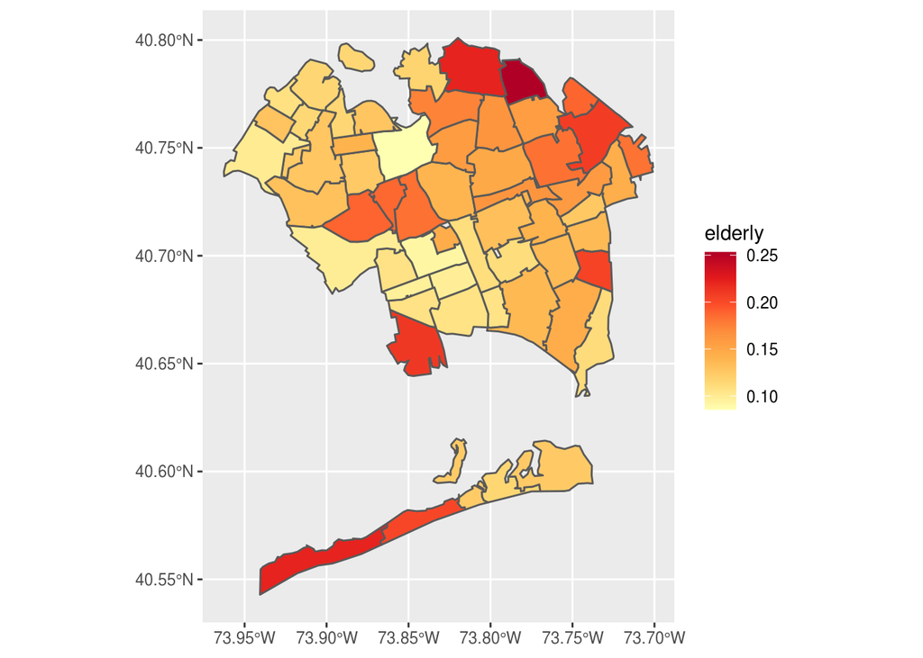

```r
queens_prop_65yrs_filtered <- queens_prop_65yrs %>%
  filter(elderly < 0.8)

ggplot(st_as_sf(queens_prop_65yrs_filtered), aes(fill = elderly)) +
  geom_sf() +
  scale_fill_distiller(palette = "YlOrRd",
                       direction = 1)
```

*Merge Dataframes Queens*

```r
df_list_queens <- list(queens_uninsured, queens_med_income, queens_prop_white, queens_prop_4, queens_prop_bus, queens_prop_65yrs)

all_df_queens <- df_list_queens %>%
  reduce(full_join, by = "GEOID") %>%
  select(GEOID, uninsured, med_income, white, large_house, prop_bus, elderly)

lm_all_queens <- merge(all_df_queens, april_1, by = "GEOID") %>%
  select(GEOID, uninsured:pos_prop)
```

*Univariate Linear Models*

**Proportion of 4-Person Household**

```r
lmfit_queens_4 <- lm(pos_prop ~ large_house, data = lm_all_queens)

summary(lmfit_queens_4)
```

```
##
## Call:
## lm(formula = pos_prop ~ large_house, data = lm_all_queens)
##
## Residuals:
##       Min        1Q    Median        3Q       Max
## -0.154861 -0.042149  0.002695  0.038524  0.172214
##
## Coefficients:
##             Estimate Std. Error t value Pr(>|t|)
## (Intercept)  0.44213    0.03097  14.278  < 2e-16 ***
## large_house  0.42104    0.10172   4.139 0.000118 ***
## ---
## Signif. codes:  0 '***' 0.001 '**' 0.01 '*' 0.05 '.' 0.1 ' ' 1
##
## Residual standard error: 0.07361 on 56 degrees of freedom
## Multiple R-squared:  0.2343, Adjusted R-squared:  0.2206
## F-statistic: 17.13 on 1 and 56 DF,  p-value: 0.0001184
```

**Proportion of People 18-64 Years Old that are Uninsured**

```r
lmfit_queens_uninsured <- lm(pos_prop ~ uninsured, data = lm_all_queens)

summary(lmfit_queens_uninsured)
```

```
##
## Call:
## lm(formula = pos_prop ~ uninsured, data = lm_all_queens)
##
## Residuals:
##       Min        1Q    Median        3Q       Max
## -0.135999 -0.050234 -0.002113  0.064803  0.142482
##
## Coefficients:
##             Estimate Std. Error t value Pr(>|t|)
## (Intercept)  0.48923    0.02452  19.948  < 2e-16 ***
## uninsured    0.45596    0.13649   3.341  0.00149 **
## ---
## Signif. codes:  0 '***' 0.001 '**' 0.01 '*' 0.05 '.' 0.1 ' ' 1
##
## Residual standard error: 0.07681 on 56 degrees of freedom
## Multiple R-squared:  0.1662, Adjusted R-squared:  0.1513
## F-statistic: 11.16 on 1 and 56 DF,  p-value: 0.001493
```

**Proportion Self-Identifying as White**

```r
lmfit_queens_white <- lm(pos_prop ~ white, data = lm_all_queens)

summary(lmfit_queens_white)
```

```
##
## Call:
## lm(formula = pos_prop ~ white, data = lm_all_queens)
##
## Residuals:
##       Min        1Q    Median        3Q       Max
## -0.137908 -0.049046 -0.003937  0.043730  0.207297
##
## Coefficients:
##             Estimate Std. Error t value Pr(>|t|)
## (Intercept)  0.63467    0.01895  33.494  < 2e-16 ***
## white       -0.16902    0.03907  -4.326 6.32e-05 ***
## ---
## Signif. codes:  0 '***' 0.001 '**' 0.01 '*' 0.05 '.' 0.1 ' ' 1
##
## Residual standard error: 0.07283 on 56 degrees of freedom
## Multiple R-squared:  0.2505, Adjusted R-squared:  0.2371
## F-statistic: 18.71 on 1 and 56 DF,  p-value: 6.315e-05
```

**Median Income**

```r
lmfit_queens_med_income <- lm(pos_prop ~ med_income, data = lm_all_queens)

summary(lmfit_queens_med_income)
```

```
##
## Call:
## lm(formula = pos_prop ~ med_income, data = lm_all_queens)
##
## Residuals:
##       Min        1Q    Median        3Q       Max
## -0.137939 -0.044277 -0.000025  0.051455  0.162919
##
## Coefficients:
##             Estimate Std. Error t value Pr(>|t|)
## (Intercept)  0.72121    0.04919  14.663  < 2e-16 ***
## med_income  -2.44296    0.74749  -3.268  0.00185 **
## ---
## Signif. codes:  0 '***' 0.001 '**' 0.01 '*' 0.05 '.' 0.1 ' ' 1
##
## Residual standard error: 0.07709 on 56 degrees of freedom
## Multiple R-squared:  0.1602, Adjusted R-squared:  0.1452
## F-statistic: 10.68 on 1 and 56 DF,  p-value: 0.001852
```

**Proportion of People Who Commute by Bus**

```r
lmfit_queens_bus <- lm(pos_prop ~ prop_bus, data = lm_all_queens)

summary(lmfit_queens_bus)
```

```
##
## Call:
## lm(formula = pos_prop ~ prop_bus, data = lm_all_queens)
##
## Residuals:
##       Min        1Q    Median        3Q       Max
## -0.173375 -0.050863 -0.004154  0.035501  0.206349
##
## Coefficients:
##             Estimate Std. Error t value Pr(>|t|)
## (Intercept)  0.48048    0.02261  21.253  < 2e-16 ***
## prop_bus     0.72299    0.17701   4.085 0.000142 ***
## ---
## Signif. codes:  0 '***' 0.001 '**' 0.01 '*' 0.05 '.' 0.1 ' ' 1
##
## Residual standard error: 0.07384 on 56 degrees of freedom
## Multiple R-squared:  0.2295, Adjusted R-squared:  0.2158
## F-statistic: 16.68 on 1 and 56 DF,  p-value: 0.000142
```

**Proportion Elderly (65+ years)**

```r
lmfit_queens_elderly <- lm(pos_prop ~ elderly, data = lm_all_queens)

summary(lmfit_queens_elderly)
```

```
##
## Call:
## lm(formula = pos_prop ~ elderly, data = lm_all_queens)
##
## Residuals:
##      Min       1Q   Median       3Q      Max
## -0.15970 -0.05421  0.00537  0.04373  0.17426
##
## Coefficients:
##             Estimate Std. Error t value Pr(>|t|)
## (Intercept)  0.69244    0.03898  17.764   <2e-16 ***
## elderly     -0.89744    0.26296  -3.413   0.0012 **
## ---
## Signif. codes:  0 '***' 0.001 '**' 0.01 '*' 0.05 '.' 0.1 ' ' 1
##
## Residual standard error: 0.07654 on 56 degrees of freedom
## Multiple R-squared:  0.1722, Adjusted R-squared:  0.1574
## F-statistic: 11.65 on 1 and 56 DF,  p-value: 0.001201
```

*Multivariate Linear Models (Table 1)*

**3 variables: median income, 4- or more person household, bus**

```r
lmfit_best_queens <- lm(pos_prop ~ med_income + large_house + prop_bus, data = lm_all_queens)

summary(lmfit_best_queens)
```

```
##
## Call:
## lm(formula = pos_prop ~ med_income + large_house + prop_bus,
##     data = lm_all_queens)
##
## Residuals:
##       Min        1Q    Median        3Q       Max
## -0.125285 -0.042766  0.000542  0.035612  0.163064
##
## Coefficients:
##             Estimate Std. Error t value Pr(>|t|)
## (Intercept)  0.57905    0.05066  11.431 4.87e-16 ***
## med_income  -2.19022    0.63776  -3.434  0.00115 **
## large_house  0.28868    0.11027   2.618  0.01146 *
## prop_bus     0.36746    0.19268   1.907  0.06184 .
## ---
## Signif. codes:  0 '***' 0.001 '**' 0.01 '*' 0.05 '.' 0.1 ' ' 1
##
## Residual standard error: 0.06519 on 54 degrees of freedom
## Multiple R-squared:  0.4209, Adjusted R-squared:  0.3887
## F-statistic: 13.08 on 3 and 54 DF,  p-value: 1.552e-06
```

# Mobility Data

*Safegraph Data*

```r
load('/data/safegraph/safegraph.Rdata')

safegraph <- safegraph %>%
  rename(GEOID = postal_code) %>%
  merge(nyc_zip_codes, by = "GEOID")
```

*February*

```r
february <- safegraph %>%
  filter(month(date)==2) %>%
  arrange(GEOID, date)
```

```r
med_feb <- february %>%
  group_by(GEOID) %>%
  summarize(median = median(avg_visits_per_day))
```

*March & April*

```r
mar_apr <- safegraph %>%
  filter(month(date)==3 | month(date)==4) %>%
  arrange(GEOID, date)
```

*Change in Mobility Calculations*

```r
mobility <- merge(mar_apr, med_feb, by = "GEOID") %>%
  mutate(change = (avg_visits_per_day-median)/median)
```

## Linear Models with Mobility

**Manhattan**

```r
all_variables_manhattan <- merge(lm_all_manhattan, mobility, by = "GEOID") %>%
  filter(is.finite(change), date == "2020-04-01")
```

```r
lm_mobility_manhattan <- lm(pos_prop ~ change, data = all_variables_manhattan)

summary(lm_mobility_manhattan)
```

```
##
## Call:
## lm(formula = pos_prop ~ change, data = all_variables_manhattan)
##
## Residuals:
##      Min       1Q   Median       3Q      Max
## -0.13167 -0.04867 -0.01102  0.04634  0.13550
##
## Coefficients:
##             Estimate Std. Error t value Pr(>|t|)
## (Intercept)  0.59905    0.05823  10.287 8.49e-13 ***
## change       0.25221    0.08096   3.115  0.00339 **
## ---
## Signif. codes:  0 '***' 0.001 '**' 0.01 '*' 0.05 '.' 0.1 ' ' 1
##
## Residual standard error: 0.06739 on 40 degrees of freedom
## Multiple R-squared:  0.1953, Adjusted R-squared:  0.1751
## F-statistic: 9.705 on 1 and 40 DF,  p-value: 0.003393
```

```r
lm_all_manhattan <- lm(pos_prop ~ uninsured + large_house + white + elderly + prop_bus + med_income, data = all_variables_manhattan)

summary(lm_all_manhattan)
```

```
##
## Call:
## lm(formula = pos_prop ~ uninsured + large_house + white + elderly +
##     prop_bus + med_income, data = all_variables_manhattan)
##
## Residuals:
##       Min        1Q    Median        3Q       Max
## -0.110543 -0.031200  0.000262  0.033437  0.120891
##
## Coefficients:
##             Estimate Std. Error t value Pr(>|t|)
## (Intercept)  0.35228    0.09770   3.606  0.00096 ***
## uninsured    1.00963    0.56561   1.785  0.08293 .
## large_house -0.12785    0.27341  -0.468  0.64296
## white       -0.13011    0.09169  -1.419  0.16472
## elderly      0.36206    0.22348   1.620  0.11418
## prop_bus    -0.25332    0.35871  -0.706  0.48474
## med_income   0.39698    0.59004   0.673  0.50550
## ---
## Signif. codes:  0 '***' 0.001 '**' 0.01 '*' 0.05 '.' 0.1 ' ' 1
##
## Residual standard error: 0.05774 on 35 degrees of freedom
## Multiple R-squared:  0.483,  Adjusted R-squared:  0.3944
## F-statistic:  5.45 on 6 and 35 DF,  p-value: 0.0004569
```

```r
lm_all_mobility_manhattan <- lm(pos_prop ~ uninsured + large_house + white + elderly + prop_bus + med_income + change, data = all_variables_manhattan)

summary(lm_all_mobility_manhattan)
```

```
##
## Call:
## lm(formula = pos_prop ~ uninsured + large_house + white + elderly +
##     prop_bus + med_income + change, data = all_variables_manhattan)
##
## Residuals:
##       Min        1Q    Median        3Q       Max
## -0.110813 -0.031262  0.000318  0.033336  0.121601
##
## Coefficients:
##              Estimate Std. Error t value Pr(>|t|)
## (Intercept)  0.347847   0.139135   2.500   0.0174 *
## uninsured    1.009849   0.573868   1.760   0.0875 .
## large_house -0.125066   0.284097  -0.440   0.6626
## white       -0.133224   0.115586  -1.153   0.2571
## elderly      0.364403   0.232539   1.567   0.1264
## prop_bus    -0.245414   0.403509  -0.608   0.5471
## med_income   0.409085   0.655415   0.624   0.5367
## change      -0.005731   0.126300  -0.045   0.9641
## ---
## Signif. codes:  0 '***' 0.001 '**' 0.01 '*' 0.05 '.' 0.1 ' ' 1
##
## Residual standard error: 0.05858 on 34 degrees of freedom
## Multiple R-squared:  0.4831, Adjusted R-squared:  0.3766
## F-statistic: 4.539 on 7 and 34 DF,  p-value: 0.001158
```

```r
lm_best_mobility_manhattan <- lm(pos_prop ~ uninsured + white + med_income + change, data = all_variables_manhattan)

summary(lm_best_mobility_manhattan)
```

```
##
## Call:
## lm(formula = pos_prop ~ uninsured + white + med_income + change,
##     data = all_variables_manhattan)
##
## Residuals:
##       Min        1Q    Median        3Q       Max
## -0.137868 -0.042224  0.008708  0.035894  0.111203
##
## Coefficients:
##             Estimate Std. Error t value Pr(>|t|)
## (Intercept)  0.40676    0.10843   3.751 0.000602 ***
## uninsured    0.70432    0.43480   1.620 0.113757
## white       -0.05551    0.08957  -0.620 0.539213
## med_income  -0.02757    0.44521  -0.062 0.950961
## change       0.02142    0.09803   0.219 0.828207
## ---
## Signif. codes:  0 '***' 0.001 '**' 0.01 '*' 0.05 '.' 0.1 ' ' 1
##
## Residual standard error: 0.0582 on 37 degrees of freedom
## Multiple R-squared:  0.4448, Adjusted R-squared:  0.3847
## F-statistic:  7.41 on 4 and 37 DF,  p-value: 0.0001729
```

**Queens**

```r
all_variables_queens <- merge(lm_all_queens, mobility, by = "GEOID") %>%
  filter(is.finite(change), date == "2020-04-01")
```

```r
lm_mobility_queens <- lm(pos_prop ~ change, data = all_variables_queens)

summary(lm_mobility_queens)
```

```
##
## Call:
## lm(formula = pos_prop ~ change, data = all_variables_queens)
##
## Residuals:
##       Min        1Q    Median        3Q       Max
## -0.177320 -0.064816  0.006106  0.048945  0.203394
##
## Coefficients:
##             Estimate Std. Error t value Pr(>|t|)
## (Intercept)  0.55352    0.01891  29.267   <2e-16 ***
## change      -0.03078    0.03757  -0.819    0.416
## ---
## Signif. codes:  0 '***' 0.001 '**' 0.01 '*' 0.05 '.' 0.1 ' ' 1
##
## Residual standard error: 0.08293 on 53 degrees of freedom
## Multiple R-squared:  0.01251,    Adjusted R-squared:  -0.006125
## F-statistic: 0.6712 on 1 and 53 DF,  p-value: 0.4163
```

```r
lm_all_queens <- lm(pos_prop ~ uninsured + large_house + white + elderly + prop_bus + med_income, data = all_variables_queens)

summary(lm_all_queens)
```

```
##
## Call:
## lm(formula = pos_prop ~ uninsured + large_house + white + elderly +
##     prop_bus + med_income, data = all_variables_queens)
##
## Residuals:
##       Min        1Q    Median        3Q       Max
## -0.128029 -0.042155  0.001467  0.039781  0.150104
##
## Coefficients:
##             Estimate Std. Error t value Pr(>|t|)
## (Intercept)  0.55364    0.09969   5.553  1.2e-06 ***
## uninsured    0.18176    0.18962   0.959    0.343
## large_house  0.20098    0.15903   1.264    0.212
## white       -0.02594    0.05909  -0.439    0.663
## elderly     -0.06983    0.33849  -0.206    0.837
## prop_bus     0.37193    0.26210   1.419    0.162
## med_income  -1.58594    1.17390  -1.351    0.183
## ---
## Signif. codes:  0 '***' 0.001 '**' 0.01 '*' 0.05 '.' 0.1 ' ' 1
##
## Residual standard error: 0.06635 on 48 degrees of freedom
## Multiple R-squared:  0.4275, Adjusted R-squared:  0.3559
## F-statistic: 5.973 on 6 and 48 DF,  p-value: 0.0001017
```

```r
lm_all_mobility_queens <- lm(pos_prop ~ uninsured + large_house + white + elderly + prop_bus + med_income + change, data = all_variables_queens)

summary(lm_all_mobility_queens)
```

```
##
## Call:
## lm(formula = pos_prop ~ uninsured + large_house + white + elderly +
##     prop_bus + med_income + change, data = all_variables_queens)
##
## Residuals:
##       Min        1Q    Median        3Q       Max
## -0.120791 -0.044028 -0.002174  0.044579  0.146576
##
## Coefficients:
##             Estimate Std. Error t value Pr(>|t|)
## (Intercept)  0.54076    0.10097   5.356  2.5e-06 ***
## uninsured    0.20259    0.19149   1.058    0.295
## large_house  0.17885    0.16133   1.109    0.273
## white       -0.02294    0.05932  -0.387    0.701
## elderly     -0.13985    0.34833  -0.401    0.690
## prop_bus     0.39172    0.26364   1.486    0.144
## med_income  -1.41396    1.19246  -1.186    0.242
## change      -0.02763    0.03119  -0.886    0.380
## ---
## Signif. codes:  0 '***' 0.001 '**' 0.01 '*' 0.05 '.' 0.1 ' ' 1
##
## Residual standard error: 0.0665 on 47 degrees of freedom
## Multiple R-squared:  0.4369, Adjusted R-squared:  0.353
## F-statistic: 5.209 on 7 and 47 DF,  p-value: 0.0001912
```

```r
lm_best_mobility_queens <- lm(pos_prop ~ med_income + large_house + prop_bus + change, data = all_variables_queens)

summary(lm_best_mobility_queens)
```

```
##
## Call:
## lm(formula = pos_prop ~ med_income + large_house + prop_bus +
##     change, data = all_variables_queens)
##
## Residuals:
##       Min        1Q    Median        3Q       Max
## -0.121765 -0.045411 -0.003571  0.040396  0.158993
##
## Coefficients:
##             Estimate Std. Error t value Pr(>|t|)
## (Intercept)  0.58479    0.05482  10.668 1.75e-14 ***
## med_income  -2.42505    0.71887  -3.373  0.00144 **
## large_house  0.29451    0.11204   2.629  0.01136 *
## prop_bus     0.33888    0.20181   1.679  0.09936 .
## change      -0.02222    0.02969  -0.748  0.45770
## ---
## Signif. codes:  0 '***' 0.001 '**' 0.01 '*' 0.05 '.' 0.1 ' ' 1
##
## Residual standard error: 0.06539 on 50 degrees of freedom
## Multiple R-squared:  0.4208, Adjusted R-squared:  0.3745
## F-statistic: 9.083 on 4 and 50 DF,  p-value: 1.353e-05
```